# Results: Program 1

Final model for hypothesis 1

The PHREG Procedure

| Model Information |  |
| --- | --- |
| Data Set | WORK.MIDTERM |
| Dependent Variable | age_dep |
| Censoring Variable | DSMDEPHR |
| Censoring Value(s) | 0 |
| Ties Handling | EFRON |

| Number of Observations Read Number of Observations Used | 220 220 |
| --- | --- |

| Class Level Information Class | Class Level Information Value | Class Level Information Design Variables |
| --- | --- | --- |
| PARDEP | 0 | 1 |
|  | 1 | 0 |
| PTSEX | 1 | 0 |
|  | 2 | 1 |
| parentms | 1 | 0 |
|  | 2 | 1 |

| Summary of the Number of Event and Censored Values Stratum | Summary of the Number of Event and Censored Values sesclass_new | Summary of the Number of Event and Censored Values Total | Summary of the Number of Event and Censored Values Event | Summary of the Number of Event and Censored Values Censored | Summary of the Number of Event and Censored Values Percent Censored |
| --- | --- | --- | --- | --- | --- |
| 1 | 1 | 17 | 3 | 14 | 82.35 |
| 2 | 2 | 38 | 11 | 27 | 71.05 |
| 3 | 3 | 48 | 19 | 29 | 60.42 |
| 4 | 4 | 97 | 31 | 66 | 68.04 |
| 5 | 5 | 20 | 5 | 15 | 75.00 |
| Total |  | 220 | 69 | 151 | 68.64 |

| Convergence Status |
| --- |
| Convergence criterion (GCONV=1E-8) satisfied. |

| Model Fit Statistics Criterion | Model Fit Statistics Without Covariates | Model Fit Statistics With Covariates |
| --- | --- | --- |
| -2 LOG L | 472.215 | 452.797 |
| AIC | 472.215 | 460.797 |
| SBC | 472.215 | 469.733 |

| Testing Global Null Hypothesis: BETA=0 Test | Testing Global Null Hypothesis: BETA=0 Chi-Square | Testing Global Null Hypothesis: BETA=0 DF | Testing Global Null Hypothesis: BETA=0 Pr > ChiSq |
| --- | --- | --- | --- |
| Likelihood Ratio | 19.4181 | 4 | 0.0007 |
| Score | 17.9531 | 4 | 0.0013 |
| Wald | 15.0374 | 4 | 0.0046 |

| Type 3 Tests Effect | Type 3 Tests DF | Type 3 Tests Wald Chi-Square | Type 3 Tests Pr > ChiSq |
| --- | --- | --- | --- |
| PARDEP | 1 | 1.3614 | 0.2433 |
| PTSEX | 1 | 4.8303 | 0.0280 |
| parentms | 1 | 0.0467 | 0.8288 |
| prepubertyonset | 1 | 4.7025 | 0.0301 |

| Analysis of Maximum Likelihood Estimates Parameter | Analysis of Maximum Likelihood Estimates | Analysis of Maximum Likelihood Estimates DF | Analysis of Maximum Likelihood Estimates Parameter Estimate | Analysis of Maximum Likelihood Estimates Standard Error | Analysis of Maximum Likelihood Estimates Chi-Square | Analysis of Maximum Likelihood Estimates Pr > ChiSq | Analysis of Maximum Likelihood Estimates Hazard Ratio | Analysis of Maximum Likelihood Estimates Label |
| --- | --- | --- | --- | --- | --- | --- | --- | --- |
| PARDEP | 0 | 1 | -0.36784 | 0.31527 | 1.3614 | 0.2433 | 0.692 | PARDEP 0 |
| PTSEX | 2 | 1 | 0.57555 | 0.26188 | 4.8303 | 0.0280 | 1.778 | PTSEX 2 |
| parentms | 2 | 1 | -0.06473 | 0.29939 | 0.0467 | 0.8288 | 0.937 | parentms 2 |
| prepubertyonset |  | 1 | 1.51710 | 0.69960 | 4.7025 | 0.0301 | 4.559 |  |

| Estimate Label | Estimate | Estimate Standard Error | Estimate z Value | Estimate Pr > \|z\| | Estimate Alpha | Estimate Lower | Estimate Upper | Estimate Exponentiated | Estimate Exponentiated Lower | Estimate Exponentiated Upper |
| --- | --- | --- | --- | --- | --- | --- | --- | --- | --- | --- |
| HR before 13 | 1.1493 | 0.8840 | 1.30 | 0.1936 | 0.05 | -0.5833 | 2.8818 | 3.1558 | 0.5581 | 17.8462 |

| Estimate Label | Estimate | Estimate Standard Error | Estimate z Value | Estimate Pr > \|z\| | Estimate Alpha | Estimate Lower | Estimate Upper | Estimate Exponentiated | Estimate Exponentiated Lower | Estimate Exponentiated Upper |
| --- | --- | --- | --- | --- | --- | --- | --- | --- | --- | --- |
| HR after 13 | -0.3678 | 0.3153 | -1.17 | 0.2433 | 0.05 | -0.9858 | 0.2501 | 0.6922 | 0.3732 | 1.2841 |

Final model for hypothesis 2

The PHREG Procedure

| Model Information |  |
| --- | --- |
| Data Set | WORK.MIDTERM |
| Dependent Variable | age_SA |
| Censoring Variable | DSMSUBHR |
| Censoring Value(s) | 0 |
| Ties Handling | EFRON |

| Number of Observations Read Number of Observations Used | 220 220 |
| --- | --- |

| Class Level Information Class | Class Level Information Value | Class Level Information Design Variables | Class Level Information Design Variables | Class Level Information Design Variables | Class Level Information Design Variables |
| --- | --- | --- | --- | --- | --- |
| PARDEP | 0 | 1 |  |  |  |
|  | 1 | 0 |  |  |  |
| PTSEX | 1 | 0 |  |  |  |
|  | 2 | 1 |  |  |  |
| parentms | 1 | 0 |  |  |  |
|  | 2 | 1 |  |  |  |
| sesclass_new | 1 | 0 | 0 | 0 | 0 |
|  | 2 | 1 | 0 | 0 | 0 |
|  | 3 | 0 | 1 | 0 | 0 |
|  | 4 | 0 | 0 | 1 | 0 |
|  | 5 | 0 | 0 | 0 | 1 |

| Summary of the Number of Event and Censored Values Total | Summary of the Number of Event and Censored Values Event | Summary of the Number of Event and Censored Values Censored | Summary of the Number of Event and Censored Values Percent Censored |
| --- | --- | --- | --- |
| 220 | 28 | 192 | 87.27 |

| Convergence Status |
| --- |
| Convergence criterion (GCONV=1E-8) satisfied. |

| Model Fit Statistics Criterion | Model Fit Statistics Without Covariates | Model Fit Statistics With Covariates |
| --- | --- | --- |
| -2 LOG L | 243.632 | 227.440 |
| AIC | 243.632 | 243.440 |
| SBC | 243.632 | 254.097 |

| Testing Global Null Hypothesis: BETA=0 Test | Testing Global Null Hypothesis: BETA=0 Chi-Square | Testing Global Null Hypothesis: BETA=0 DF | Testing Global Null Hypothesis: BETA=0 Pr > ChiSq |
| --- | --- | --- | --- |
| Likelihood Ratio | 16.1920 | 8 | 0.0397 |
| Score | 12.3683 | 8 | 0.1355 |
| Wald | 7.0841 | 8 | 0.5276 |

| Type 3 Tests Effect | Type 3 Tests DF | Type 3 Tests Wald Chi-Square | Type 3 Tests Pr > ChiSq |
| --- | --- | --- | --- |
| PARDEP | 1 | 2.9049 | 0.0883 |
| priordep | 1 | 0.2438 | 0.6215 |
| PTSEX | 1 | 0.4018 | 0.5262 |
| parentms | 1 | 3.1026 | 0.0782 |
| sesclass_new | 4 | 0.6080 | 0.9622 |

| Analysis of Maximum Likelihood Estimates Parameter | Analysis of Maximum Likelihood Estimates | Analysis of Maximum Likelihood Estimates DF | Analysis of Maximum Likelihood Estimates Parameter Estimate | Analysis of Maximum Likelihood Estimates Standard Error | Analysis of Maximum Likelihood Estimates Chi-Square | Analysis of Maximum Likelihood Estimates Pr > ChiSq | Analysis of Maximum Likelihood Estimates Hazard Ratio | Analysis of Maximum Likelihood Estimates 95% Hazard Ratio Confidence Limits | Analysis of Maximum Likelihood Estimates 95% Hazard Ratio Confidence Limits | Analysis of Maximum Likelihood Estimates Label |
| --- | --- | --- | --- | --- | --- | --- | --- | --- | --- | --- |
| PARDEP | 0 | 1 | -0.84542 | 0.49603 | 2.9049 | 0.0883 | 0.429 | 0.162 | 1.135 | PARDEP 0 |
| priordep |  | 1 | -0.21553 | 0.43655 | 0.2438 | 0.6215 | 0.806 | 0.343 | 1.897 |  |
| PTSEX | 2 | 1 | -0.25936 | 0.40917 | 0.4018 | 0.5262 | 0.772 | 0.346 | 1.720 | PTSEX 2 |
| parentms | 2 | 1 | -1.01827 | 0.57809 | 3.1026 | 0.0782 | 0.361 | 0.116 | 1.122 | parentms 2 |
| sesclass_new | 2 | 1 | -15.10428 | 1002 | 0.0002 | 0.9880 | 0.000 | 0.000 | . | sesclass_new 2 |
| sesclass_new | 3 | 1 | 0.24458 | 0.71318 | 0.1176 | 0.7316 | 1.277 | 0.316 | 5.168 | sesclass_new 3 |
| sesclass_new | 4 | 1 | 0.12334 | 0.68428 | 0.0325 | 0.8570 | 1.131 | 0.296 | 4.325 | sesclass_new 4 |
| sesclass_new | 5 | 1 | -0.37565 | 0.94698 | 0.1574 | 0.6916 | 0.687 | 0.107 | 4.395 | sesclass_new 5 |

Kaplan-Meier Curve for Depression Onset by Parental Depression

The LIFETEST Procedure

Stratum 1: PARDEP = 0

| Product-Limit Survival Estimates age_dep | Product-Limit Survival Estimates | Product-Limit Survival Estimates Survival | Product-Limit Survival Estimates Failure | Product-Limit Survival Estimates Survival Standard Error | Product-Limit Survival Estimates Number Failed | Product-Limit Survival Estimates Number Left |
| --- | --- | --- | --- | --- | --- | --- |
| 0.0000 |  | 1.0000 | 0 | 0 | 0 | 95 |
| 7.0000 | * | . | . | . | 0 | 94 |
| 8.0000 | * | . | . | . | 0 | 93 |
| 9.0000 | * | . | . | . | 0 | 92 |
| 9.0000 | * | . | . | . | 0 | 91 |
| 10.0000 | * | . | . | . | 0 | 90 |
| 10.0000 | * | . | . | . | 0 | 89 |
| 11.0000 | * | . | . | . | 0 | 88 |
| 11.0000 | * | . | . | . | 0 | 87 |
| 11.0000 | * | . | . | . | 0 | 86 |
| 11.0000 | * | . | . | . | 0 | 85 |
| 11.0000 | * | . | . | . | 0 | 84 |
| 12.0000 |  | . | . | . | 1 | 83 |
| 12.0000 |  | . | . | . | 2 | 82 |
| 12.0000 |  | 0.9643 | 0.0357 | 0.0202 | 3 | 81 |
| 12.0000 | * | . | . | . | 3 | 80 |
| 12.0000 | * | . | . | . | 3 | 79 |
| 12.0000 | * | . | . | . | 3 | 78 |
| 12.0000 | * | . | . | . | 3 | 77 |
| 12.0000 | * | . | . | . | 3 | 76 |
| 13.0000 |  | 0.9516 | 0.0484 | 0.0236 | 4 | 75 |
| 13.0000 | * | . | . | . | 4 | 74 |
| 13.0000 | * | . | . | . | 4 | 73 |
| 13.0000 | * | . | . | . | 4 | 72 |
| 13.0000 | * | . | . | . | 4 | 71 |
| 13.0000 | * | . | . | . | 4 | 70 |
| 13.0000 | * | . | . | . | 4 | 69 |
| 14.0000 |  | . | . | . | 5 | 68 |
| 14.0000 |  | 0.9240 | 0.0760 | 0.0299 | 6 | 67 |
| 14.0000 | * | . | . | . | 6 | 66 |

[output cut: 66 more lines]

Note:The marked survival times are censored observations.

Summary Statistics for Time Variable age_dep

| Quartile Estimates Percent | Quartile Estimates Point Estimate | Quartile Estimates 95% Confidence Interval Transform | Quartile Estimates 95% Confidence Interval [Lower | Quartile Estimates 95% Confidence Interval Upper) |
| --- | --- | --- | --- | --- |
| 75 | . | LOGLOG | 23.0000 | . |
| 50 | 23.0000 | LOGLOG | 19.0000 | . |
| 25 | 18.0000 | LOGLOG | 17.0000 | 19.0000 |

| Mean | Standard Error |
| --- | --- |
| 20.6223 | 0.4352 |

Note:The mean survival time and its standard error were underestimated because the largest observation was censored and the estimation was restricted to the largest event time.

Kaplan-Meier Curve for Depression Onset by Parental Depression

The LIFETEST Procedure

Stratum 2: PARDEP = 1

| Product-Limit Survival Estimates age_dep | Product-Limit Survival Estimates | Product-Limit Survival Estimates Survival | Product-Limit Survival Estimates Failure | Product-Limit Survival Estimates Survival Standard Error | Product-Limit Survival Estimates Number Failed | Product-Limit Survival Estimates Number Left |
| --- | --- | --- | --- | --- | --- | --- |
| 0.0000 |  | 1.0000 | 0 | 0 | 0 | 125 |
| 4.0000 |  | 0.9920 | 0.00800 | 0.00797 | 1 | 124 |
| 5.0000 |  | 0.9840 | 0.0160 | 0.0112 | 2 | 123 |
| 5.0000 | * | . | . | . | 2 | 122 |
| 6.0000 |  | 0.9759 | 0.0241 | 0.0137 | 3 | 121 |
| 6.0000 | * | . | . | . | 3 | 120 |
| 6.0000 | * | . | . | . | 3 | 119 |
| 7.0000 |  | . | . | . | 4 | 118 |
| 7.0000 |  | . | . | . | 5 | 117 |
| 7.0000 |  | . | . | . | 6 | 116 |
| 7.0000 |  | 0.9431 | 0.0569 | 0.0209 | 7 | 115 |
| 7.0000 | * | . | . | . | 7 | 114 |
| 7.0000 | * | . | . | . | 7 | 113 |
| 7.0000 | * | . | . | . | 7 | 112 |
| 7.0000 | * | . | . | . | 7 | 111 |
| 8.0000 |  | . | . | . | 8 | 110 |
| 8.0000 |  | 0.9261 | 0.0739 | 0.0237 | 9 | 109 |
| 8.0000 | * | . | . | . | 9 | 108 |
| 8.0000 | * | . | . | . | 9 | 107 |
| 8.0000 | * | . | . | . | 9 | 106 |
| 8.0000 | * | . | . | . | 9 | 105 |
| 9.0000 |  | 0.9173 | 0.0827 | 0.0251 | 10 | 104 |
| 9.0000 | * | . | . | . | 10 | 103 |
| 9.0000 | * | . | . | . | 10 | 102 |
| 9.0000 | * | . | . | . | 10 | 101 |
| 9.0000 | * | . | . | . | 10 | 100 |
| 9.0000 | * | . | . | . | 10 | 99 |
| 10.0000 |  | . | . | . | 11 | 98 |
| 10.0000 |  | . | . | . | 12 | 97 |
| 10.0000 |  | . | . | . | 13 | 96 |

[output cut: 96 more lines]

Note:The marked survival times are censored observations.

Summary Statistics for Time Variable age_dep

| Quartile Estimates Percent | Quartile Estimates Point Estimate | Quartile Estimates 95% Confidence Interval Transform | Quartile Estimates 95% Confidence Interval [Lower | Quartile Estimates 95% Confidence Interval Upper) |
| --- | --- | --- | --- | --- |
| 75 | . | LOGLOG | . | . |
| 50 | 20.0000 | LOGLOG | 17.0000 | . |
| 25 | 13.0000 | LOGLOG | 12.0000 | 15.0000 |

| Mean | Standard Error |
| --- | --- |
| 17.1593 | 0.4669 |

Note:The mean survival time and its standard error were underestimated because the largest observation was censored and the estimation was restricted to the largest event time.

| Summary of the Number of Censored and Uncensored Values Stratum | Summary of the Number of Censored and Uncensored Values PARDEP | Summary of the Number of Censored and Uncensored Values Total | Summary of the Number of Censored and Uncensored Values Failed | Summary of the Number of Censored and Uncensored Values Censored | Summary of the Number of Censored and Uncensored Values Percent Censored |
| --- | --- | --- | --- | --- | --- |
| 1 | 0 | 95 | 22 | 73 | 76.84 |
| 2 | 1 | 125 | 47 | 78 | 62.40 |
| Total |  | 220 | 69 | 151 | 68.64 |

Kaplan-Meier Curve for Depression Onset by Parental Depression

The LIFETEST Procedure

Testing Homogeneity of Survival Curves for age_dep over Strata

| Rank Statistics PARDEP | Rank Statistics Log-Rank | Rank Statistics Wilcoxon |
| --- | --- | --- |
| 0 | -11.262 | -2276.0 |
| 1 | 11.262 | 2276.0 |

| Covariance Matrix for the Log-Rank Statistics PARDEP | Covariance Matrix for the Log-Rank Statistics 0 | Covariance Matrix for the Log-Rank Statistics 1 |
| --- | --- | --- |
| 0 | 16.4979 | -16.4979 |
| 1 | -16.4979 | 16.4979 |

| Covariance Matrix for the Wilcoxon Statistics PARDEP | Covariance Matrix for the Wilcoxon Statistics 0 | Covariance Matrix for the Wilcoxon Statistics 1 |
| --- | --- | --- |
| 0 | 340944 | -340944 |
| 1 | -340944 | 340944 |

| Test of Equality over Strata Test | Test of Equality over Strata Chi-Square | Test of Equality over Strata DF | Test of Equality over Strata Pr > Chi-Square |
| --- | --- | --- | --- |
| Log-Rank | 7.6876 | 1 | 0.0056 |
| Wilcoxon | 15.1936 | 1 | <.0001 |
| -2Log(LR) | 5.7178 | 1 | 0.0168 |

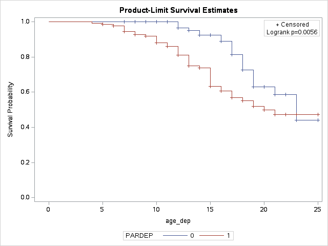

Kaplan-Meier Curve for Substance Abuse Onset by Parental Depression

The LIFETEST Procedure

Stratum 1: PARDEP = 0

| Product-Limit Survival Estimates age_SA | Product-Limit Survival Estimates | Product-Limit Survival Estimates Survival | Product-Limit Survival Estimates Failure | Product-Limit Survival Estimates Survival Standard Error | Product-Limit Survival Estimates Number Failed | Product-Limit Survival Estimates Number Left |
| --- | --- | --- | --- | --- | --- | --- |
| 0.0000 |  | 1.0000 | 0 | 0 | 0 | 95 |
| 7.0000 | * | . | . | . | 0 | 94 |
| 8.0000 | * | . | . | . | 0 | 93 |
| 9.0000 | * | . | . | . | 0 | 92 |
| 9.0000 | * | . | . | . | 0 | 91 |
| 10.0000 | * | . | . | . | 0 | 90 |
| 10.0000 | * | . | . | . | 0 | 89 |
| 11.0000 | * | . | . | . | 0 | 88 |
| 11.0000 | * | . | . | . | 0 | 87 |
| 11.0000 | * | . | . | . | 0 | 86 |
| 11.0000 | * | . | . | . | 0 | 85 |
| 11.0000 | * | . | . | . | 0 | 84 |
| 12.0000 |  | 0.9881 | 0.0119 | 0.0118 | 1 | 83 |
| 12.0000 | * | . | . | . | 1 | 82 |
| 12.0000 | * | . | . | . | 1 | 81 |
| 12.0000 | * | . | . | . | 1 | 80 |
| 12.0000 | * | . | . | . | 1 | 79 |
| 12.0000 | * | . | . | . | 1 | 78 |
| 13.0000 | * | . | . | . | 1 | 77 |
| 13.0000 | * | . | . | . | 1 | 76 |
| 13.0000 | * | . | . | . | 1 | 75 |
| 13.0000 | * | . | . | . | 1 | 74 |
| 13.0000 | * | . | . | . | 1 | 73 |
| 13.0000 | * | . | . | . | 1 | 72 |
| 13.0000 | * | . | . | . | 1 | 71 |
| 14.0000 | * | . | . | . | 1 | 70 |
| 14.0000 | * | . | . | . | 1 | 69 |
| 14.0000 | * | . | . | . | 1 | 68 |
| 14.0000 | * | . | . | . | 1 | 67 |
| 14.0000 | * | . | . | . | 1 | 66 |

[output cut: 66 more lines]

Note:The marked survival times are censored observations.

Summary Statistics for Time Variable age_SA

| Quartile Estimates Percent | Quartile Estimates Point Estimate | Quartile Estimates 95% Confidence Interval Transform | Quartile Estimates 95% Confidence Interval [Lower | Quartile Estimates 95% Confidence Interval Upper) |
| --- | --- | --- | --- | --- |
| 75 | . | LOGLOG | . | . |
| 50 | . | LOGLOG | . | . |
| 25 | . | LOGLOG | 19.5000 | . |

| Mean | Standard Error |
| --- | --- |
| 20.1003 | 0.1762 |

Note:The mean survival time and its standard error were underestimated because the largest observation was censored and the estimation was restricted to the largest event time.

Kaplan-Meier Curve for Substance Abuse Onset by Parental Depression

The LIFETEST Procedure

Stratum 2: PARDEP = 1

| Product-Limit Survival Estimates age_SA | Product-Limit Survival Estimates | Product-Limit Survival Estimates Survival | Product-Limit Survival Estimates Failure | Product-Limit Survival Estimates Survival Standard Error | Product-Limit Survival Estimates Number Failed | Product-Limit Survival Estimates Number Left |
| --- | --- | --- | --- | --- | --- | --- |
| 0.0000 |  | 1.0000 | 0 | 0 | 0 | 125 |
| 5.0000 | * | . | . | . | 0 | 124 |
| 6.0000 | * | . | . | . | 0 | 123 |
| 6.0000 | * | . | . | . | 0 | 122 |
| 7.0000 | * | . | . | . | 0 | 121 |
| 7.0000 | * | . | . | . | 0 | 120 |
| 7.0000 | * | . | . | . | 0 | 119 |
| 7.0000 | * | . | . | . | 0 | 118 |
| 7.0000 | * | . | . | . | 0 | 117 |
| 8.0000 | * | . | . | . | 0 | 116 |
| 8.0000 | * | . | . | . | 0 | 115 |
| 8.0000 | * | . | . | . | 0 | 114 |
| 8.0000 | * | . | . | . | 0 | 113 |
| 9.0000 | * | . | . | . | 0 | 112 |
| 9.0000 | * | . | . | . | 0 | 111 |
| 9.0000 | * | . | . | . | 0 | 110 |
| 9.0000 | * | . | . | . | 0 | 109 |
| 9.0000 | * | . | . | . | 0 | 108 |
| 10.0000 | * | . | . | . | 0 | 107 |
| 10.0000 | * | . | . | . | 0 | 106 |
| 10.0000 | * | . | . | . | 0 | 105 |
| 11.0000 | * | . | . | . | 0 | 104 |
| 11.0000 | * | . | . | . | 0 | 103 |
| 11.0000 | * | . | . | . | 0 | 102 |
| 11.0000 | * | . | . | . | 0 | 101 |
| 12.0000 |  | . | . | . | 1 | 100 |
| 12.0000 |  | 0.9802 | 0.0198 | 0.0139 | 2 | 99 |
| 12.0000 | * | . | . | . | 2 | 98 |
| 12.0000 | * | . | . | . | 2 | 97 |
| 12.0000 | * | . | . | . | 2 | 96 |

[output cut: 96 more lines]

Note:The marked survival times are censored observations.

Summary Statistics for Time Variable age_SA

| Quartile Estimates Percent | Quartile Estimates Point Estimate | Quartile Estimates 95% Confidence Interval Transform | Quartile Estimates 95% Confidence Interval [Lower | Quartile Estimates 95% Confidence Interval Upper) |
| --- | --- | --- | --- | --- |
| 75 | . | LOGLOG | 23.5000 | . |
| 50 | 24.5000 | LOGLOG | 22.5000 | . |
| 25 | 21.5000 | LOGLOG | 18.0000 | 23.5000 |

| Mean | Standard Error |
| --- | --- |
| 22.2088 | 0.4429 |

Note:The mean survival time and its standard error were underestimated because the largest observation was censored and the estimation was restricted to the largest event time.

| Summary of the Number of Censored and Uncensored Values Stratum | Summary of the Number of Censored and Uncensored Values PARDEP | Summary of the Number of Censored and Uncensored Values Total | Summary of the Number of Censored and Uncensored Values Failed | Summary of the Number of Censored and Uncensored Values Censored | Summary of the Number of Censored and Uncensored Values Percent Censored |
| --- | --- | --- | --- | --- | --- |
| 1 | 0 | 95 | 7 | 88 | 92.63 |
| 2 | 1 | 125 | 21 | 104 | 83.20 |
| Total |  | 220 | 28 | 192 | 87.27 |

Kaplan-Meier Curve for Substance Abuse Onset by Parental Depression

The LIFETEST Procedure

Testing Homogeneity of Survival Curves for age_SA over Strata

| Rank Statistics PARDEP | Rank Statistics Log-Rank | Rank Statistics Wilcoxon |
| --- | --- | --- |
| 0 | -4.5189 | -560.00 |
| 1 | 4.5189 | 560.00 |

| Covariance Matrix for the Log-Rank Statistics PARDEP | Covariance Matrix for the Log-Rank Statistics 0 | Covariance Matrix for the Log-Rank Statistics 1 |
| --- | --- | --- |
| 0 | 6.54866 | -6.54866 |
| 1 | -6.54866 | 6.54866 |

| Covariance Matrix for the Wilcoxon Statistics PARDEP | Covariance Matrix for the Wilcoxon Statistics 0 | Covariance Matrix for the Wilcoxon Statistics 1 |
| --- | --- | --- |
| 0 | 95218.4 | -95218.4 |
| 1 | -95218.4 | 95218.4 |

| Test of Equality over Strata Test | Test of Equality over Strata Chi-Square | Test of Equality over Strata DF | Test of Equality over Strata Pr > Chi-Square |
| --- | --- | --- | --- |
| Log-Rank | 3.1183 | 1 | 0.0774 |
| Wilcoxon | 3.2935 | 1 | 0.0696 |
| -2Log(LR) | 4.3308 | 1 | 0.0374 |

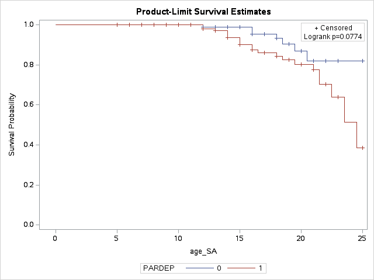